# PUMAS

Steve Simon and Satya Golla

12/30/2021

```r
library(sf)
library(tidyverse)
```

### Public Use Microdata Areas (PUMA)

```r
path_name <- "./data"
file_name <- "tl_2021_20_puma10.shp"
path_name                              %>%
  paste(file_name, sep="/")            %>%
  st_read(stringsAsFactors=FALSE)      -> all_puma_ks
head(all_puma_ks)
```

```
## Simple feature collection with 6 features and 10 fields
## Geometry type: POLYGON
## Dimension:     XY
## Bounding box:  xmin: -98.48065 ymin: 37.62876 xmax: -94.705 ymax: 39.10534
## Geodetic CRS:  NAD83
##   STATEFP10 PUMACE10 GEOID10
## 1        20    00603 2000603
## 2        20    01301 2001301
## 3        20    01000 2001000
## 4        20    00801 2000801
## 5        20    00700 2000700
## 6        20    00601 2000601
##                                                                         NAMELSAD10
## 1  Johnson County (Southwest)--Olathe, Gardner, Spring Hill & Edgerton Cities PUMA
## 2 Sedgwick (Northwest) & Harvey Counties--Wichita (Northwest) & Newton Cities PUMA
```

[output cut: 18 more lines]

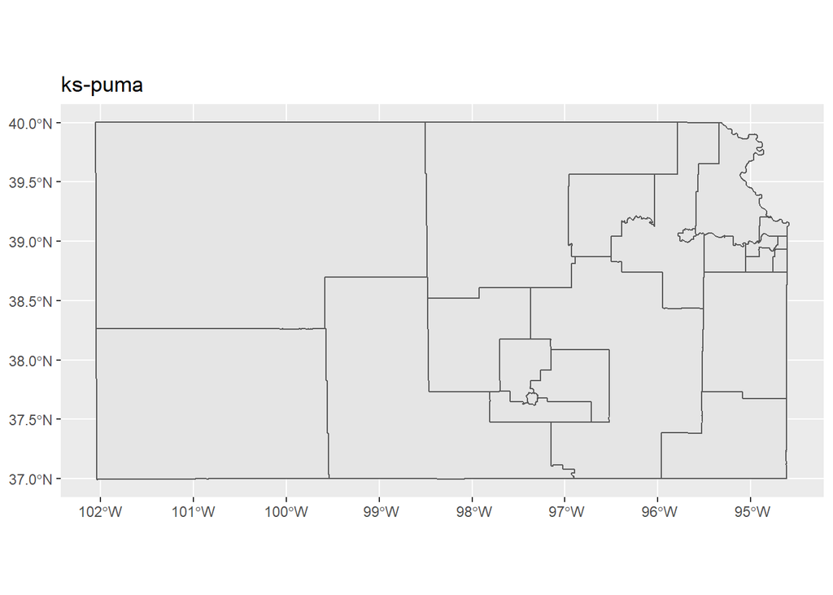

```r
all_puma_ks                           %>%
     ggplot()                              +
      geom_sf(aes())                    +
      ggtitle("ks-puma")
```

variable in the file

- Variables:
  - “STATEFP10”
  - “PUMACE10”
  - “GEOID10”
  - “NAMELSAD10”
  - “MTFCC10”
  - “FUNCSTAT10”
  - “ALAND10”
  - “AWATER10”
  - “INTPTLAT10”
  - “INTPTLON10”
  - “geometry”

```r
path_name <- "./data"
file_name <- "tl_2021_29_puma10.shp"
path_name                              %>%
  paste(file_name, sep="/")            %>%
  st_read(stringsAsFactors=FALSE)      -> all_puma_mo
head(all_puma_mo)
```

```
## Simple feature collection with 6 features and 10 fields
## Geometry type: POLYGON
## Dimension:     XY
## Bounding box:  xmin: -94.60243 ymin: 36.80918 xmax: -90.26498 ymax: 39.78906
## Geodetic CRS:  NAD83
##   STATEFP10 PUMACE10 GEOID10
## 1        29    02601 2902601
## 2        29    01804 2901804
## 3        29    01803 2901803
## 4        29    00800 2900800
## 5        29    01004 2901004
## 6        29    01002 2901002
##                                                             NAMELSAD10 MTFCC10
## 1 Christian, Greene (Outside Springfield City) & Webster Counties PUMA   G6120
## 2                                         St. Louis County (West) PUMA   G6120
```

[output cut: 18 more lines]

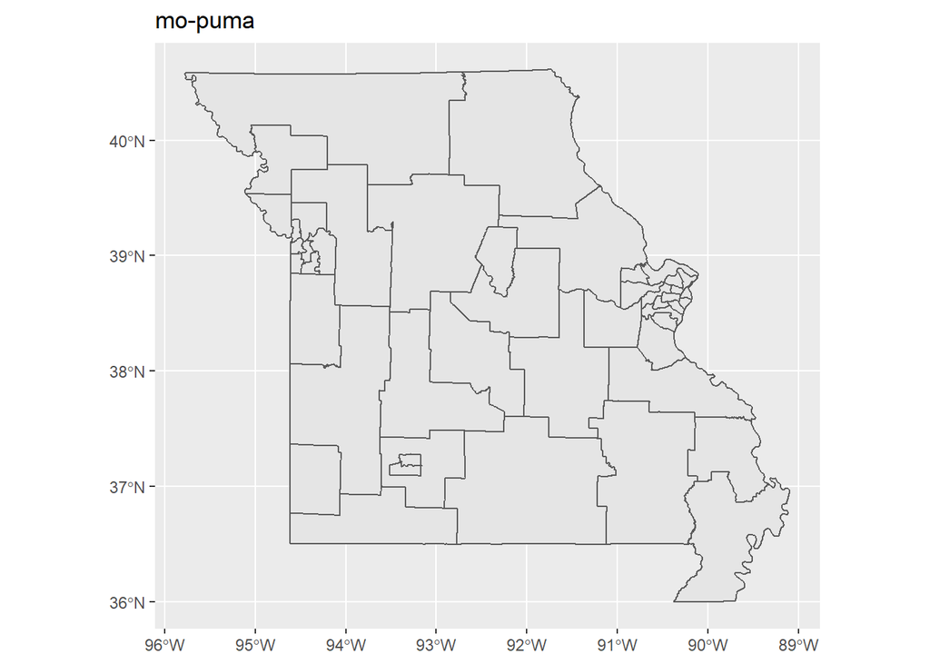

```r
all_puma_mo                           %>%
     ggplot()                              +
      geom_sf(aes())                    +
      ggtitle("mo-puma")
```

variable in the file

- Variables:
  - “STATEFP10”
  - “PUMACE10”
  - “GEOID10”
  - “NAMELSAD10”
  - “MTFCC10”
  - “FUNCSTAT10”
  - “ALAND10”
  - “AWATER10”
  - “INTPTLAT10”
  - “INTPTLON10”
  - “geometry”

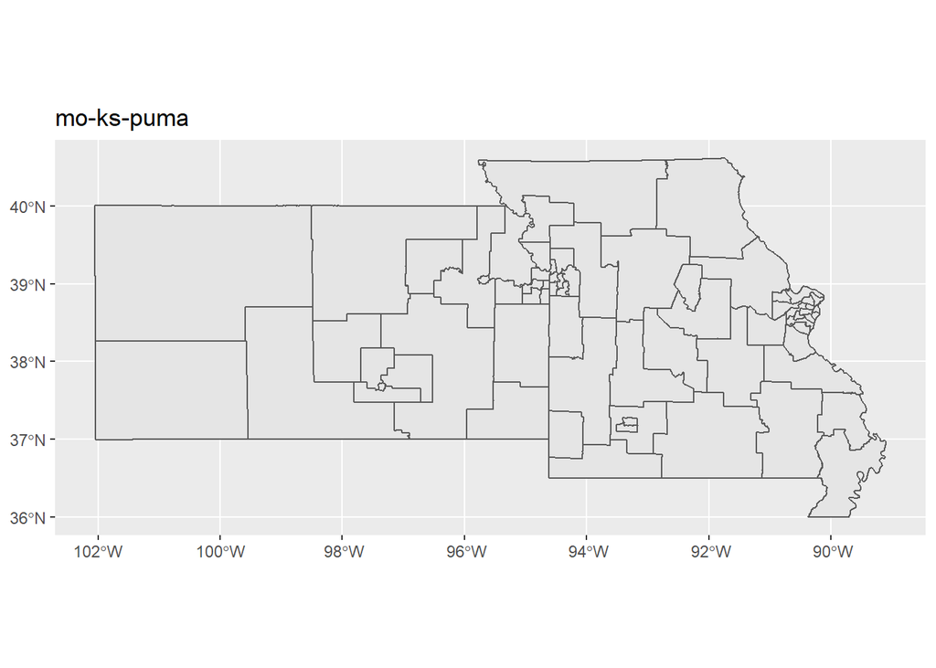

```r
all_puma_ks                %>%
  bind_rows(all_puma_mo)  -> mo_ks_puma
mo_ks_puma %>%
 ggplot()                               +
      geom_sf(aes())                    +
      ggtitle("mo-ks-puma")
```

### Community districts

This shapefile, Community_District, was provided by Neal Wilson. The various functions described in the US counties shapefiles section will be used here.

```r
file_name <- "Community_District.shp"
path_name                              %>%
  paste(file_name, sep="/")            %>%
  st_read(stringsAsFactors=FALSE)      -> Community_Districts
head(Community_Districts)
```

```
## Simple feature collection with 6 features and 8 fields
## Geometry type: POLYGON
## Dimension:     XYZ
## Bounding box:  xmin: 2758255 ymin: 1013899 xmax: 2821302 ymax: 1086876
## z_range:       zmin: 0 zmax: 0
## Projected CRS: NAD_1983_StatePlane_Missouri_West_FIPS_2403_Feet
##   State STATE_FIPS CD_ID
## 1    MO         29   106
## 2    MO         29   108
## 3    MO         29   113
## 4    MO         29   102
## 5    MO         29   129
## 6    MO         29   116
##                                                                                 shid
## 1            country:us/state:mo/place:kansas_city_city/community_district:east_side
```

[output cut: 19 more lines]

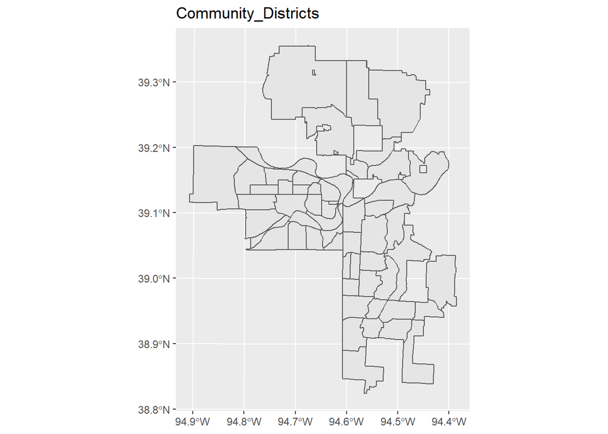

```r
Community_Districts                  %>%
  ggplot()                              +
      geom_sf(aes())                    +
      ggtitle("Community_Districts")
```

```r
Community_Districts %>%
  st_transform(crs=st_crs(mo_ks_puma)) -> cd
```

#### Intersection of pumas with community districts

Each community district will reside entirely inside a single county, and it is obvious to anyone familiar with the Kansas City metropolitan area which county is would be, so this is done mostly for the sake of continuity and completeness.

It is important that both the pumas and the community districts use a common coordinate reference system. It is unclear WHICH coordinate reference system is best, but this is controlled by the st_crs function of the sf package.

The st_intersects function will evaluate to TRUE if two shapefiles intersect. The st_area function will give the area of a shapefile and the st_intersection function will produce a new shapefile from the intersection of two shapefiles.

```
## st_as_s2(): dropping Z and/or M coordinate
```

```
## 26.15316 [m^2]
## 157.0565 [m^2]
## 0.1665207 [1]
```

```
## st_as_s2(): dropping Z and/or M coordinate
```

```
## 10.97656 [m^2]
## 157.0565 [m^2]
## 0.06988923 [1]
```

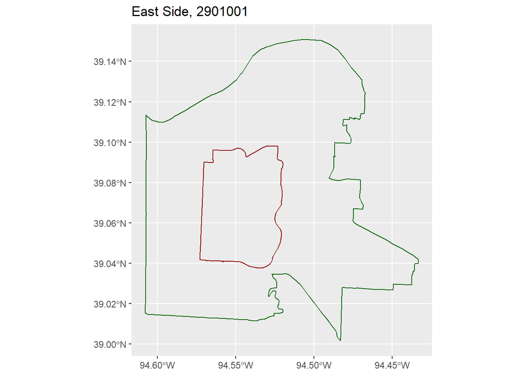

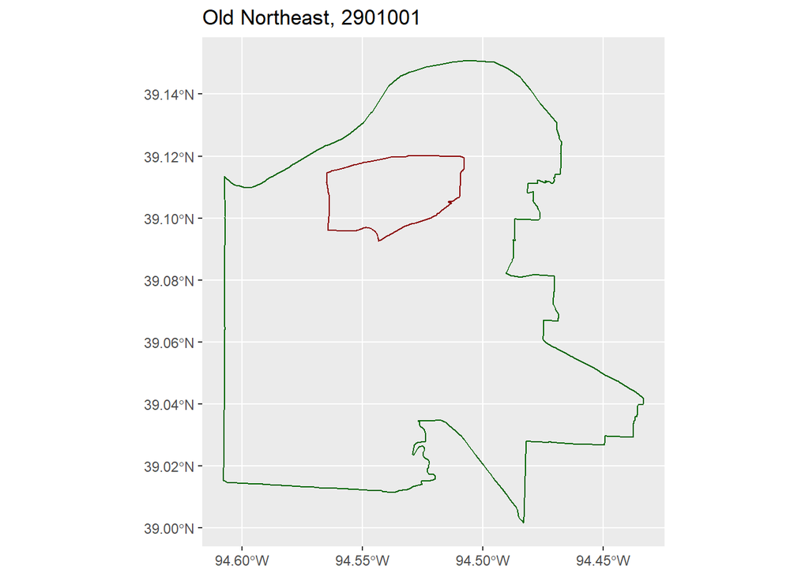

```r
for(i in 1:2) {
mo_ks_puma                             %>%
st_intersects( cd[i,], sparse=FALSE) -> intersect_matrix
  total_area  <- st_area(mo_ks_puma[intersect_matrix,]) / 1000000
  intersect_area <- st_area(st_intersection(mo_ks_puma[intersect_matrix,],cd[i,])) / 1000000
  print(intersect_area)
  print(total_area)
  print(intersect_area/total_area)
 map_position <- st_centroid(mo_ks_puma[intersect_matrix, ])
 ggplot(data=mo_ks_puma[intersect_matrix, ], aes()) +
        geom_sf(fill=NA, col="darkgreen") +
        geom_sf(data=cd[i,], fill=NA, col="darkred")+
   ggtitle(paste(c(cd$NAME[i],mo_ks_puma$GEOID10[intersect_matrix]),collapse = ", ")) -> map
   print(map)
}
```

### Neighborhoods

This shapefile, Neighborhoods, was provided by Neal Wilson. The various functions described in the US counties shapefiles section will be used here.

```r
file_name <- "Neighborhoods.shp"
path_name                              %>%
  paste(file_name, sep="/")            %>%
  st_read(stringsAsFactors=FALSE)      -> Neighborhoods
head(Neighborhoods)
Neighborhoods                          %>%
  ggplot()                              +
      geom_sf(aes())                    +
      ggtitle("Neighborhoods")
Neighborhoods                          %>%
  st_transform(crs=st_crs(mo_ks_puma)) -> nbd
```

[output not shown]